# Algo-Projekt: OKCUpid

Emanuel Elias Reckmeyer (2010837532)

# Packages laden

```r
library(readr)
library(dplyr)
library(tidyverse)
library(caret)
library(class)
```

# Einleitung:

Git: https://github.com/EliReckless/Algo-Projekt-Reckmeyer

Der OKCupid Datensatz ist mir schon seit längerem bekannt und hat viel Neugier bei mir geweckt. Am Anfang des Semesters hat der Datensatz mich aber noch überfordert und nachdem wir zu dem Zeitpunkt auch gerade erst bei der linearen Regression angekommen waren, habe ich den Datensatz wieder geparkt und etwas anderes gesucht. Nach einigem Hin und Her habe ich mir diesen Datensatz erneut angesehen und festgestellt, dass er sich sehr gut für eine Klassifikation eignen würde, da er über sehr viele Variablen verfügt, die potentiell dabei behilflich sein könnten zum beispiel zwischen Männern und Frauen zu unterscheiden. Bei der folgenden EDA wird man bereits erkennen, dass sie mein Fokus darauf richtet.

```r
# Get Dataset (link: https://www.kaggle.com/andrewmvd/okcupid-profiles/download)
okcupid_profiles <- read_csv("~/okcupid_profiles.csv")
data <- okcupid_profiles
```

# EDA

- Woher kommen diese Daten?: Dieser Datensatz stammt von Kaggle und umfasst Personen-Profile von 60.000 Usern der mobile App der Dating-Platform OKCupid. Autoren sind Albert Kim und Adriana Escobedo-Land.
- Was ist eine Beobachtung in diesem Datensatz? Jede Beobachtung entspricht einem User. Username und Profilbild sind nicht enthalten.
- Was sind die Variablen in diesem Datensatz? Der Datensatz umfasst 31 Variablen
  - age: Alter
  - status: Beziehungsstatus
  - sex: Geschlecht
  - orientation: sexuelle Orientierung
  - body_type: Beschreibung des Körpertyps
  - diet: Ernährungsweise
  - drinks: Alkoholkonsum
  - drugs: Drogenkonsum
  - education: Bildungsstand
  - ethnicity: Ethnie
  - height: Körpergröße
  - income: Einkommen
  - job: Beruf
  - last_online: letztes mal online
  - location: Standort
  - offspring: Kinder und Kinderwunsch
  - pets: Haustiere
  - religion: Religionszugehörigkeit
  - sign: Sternzeichen
  - smokes: Raucher
  - speaks: Sprachen
  - essay 0-9:
    - 0: My Self Summary
    - 1: What I’m doing with my life
    - 2: I’m really good at
    - 3: The first thing people notice about me
    - 4: Favorite books, movies, shows, music, and food
    - 5: The six things I could never do without
    - 6: I spend a lot of time thinking about
    - 7: On a typical Friday night I am
    - 8: The most private thing I’m willing to admit
    - 9: You should message me if

Schauen wir uns die diversen Variablen mittels einiger Plots genauer an:

## Alter:

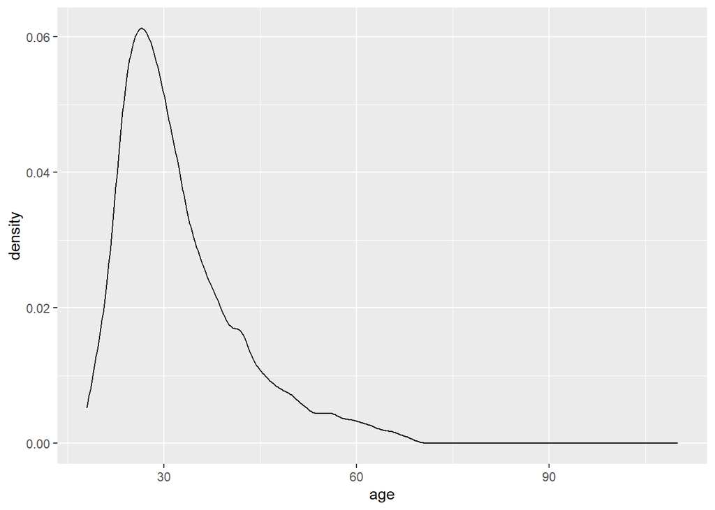

```r
ggplot(data, aes(x=age)) + geom_density()
```

```r
median_age <- median(data$age)
mean_age <- mean(data$age)

group_men <- subset(data, sex=="m")
group_women <- subset(data, sex=="f")

gender_age_group <- group_by(data, sex)%>%
  summarise(mean_age = mean(age))
```

Wir sehen, dass die meisten User eher jung sind. Durchnittsalter liegt bei 32.34 Jahren, Median bei 30. Wenn wir das Durchnittsalter nach Geschlecht aufteilen, sehen wir, dass die Frauen im Schnitt etwas älter sind (32.8) als die Männer (32).

## Beziehungsstatus:

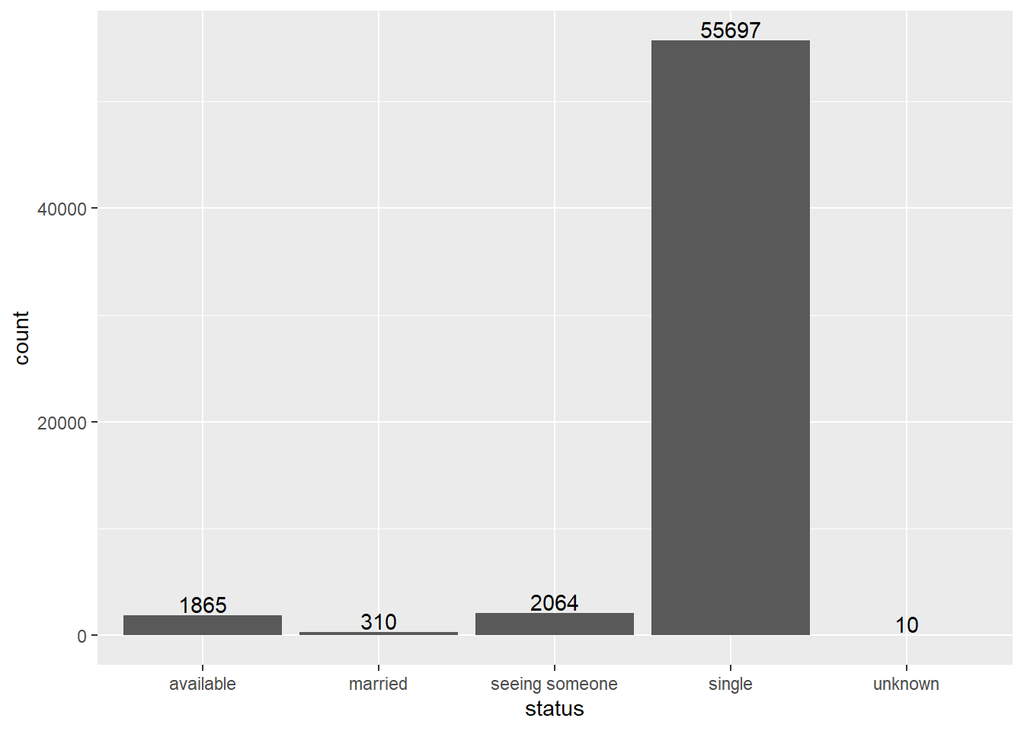

```r
ggplot(data, aes(x=status)) + geom_bar() + geom_text(stat = "count", aes(label = ..count.., vjust = -0.2))
```

Wie zu erwarten war, sind die meisten single. 1865 Personen geben an “available” zu sein, was interessant ist, da man hier wohl davon ausgehen kann, dass sie in einer offenen oder polyamörsen Beziehung leben. Die 310 Beobachtungen die angeben verheiratet zu sein fallen wohl in die selbe Kategorie oder sind auf der Suche nach einem Seitensprung. 2064 Beobachtungen scheinen in einer Beziehung zu sein, behalten aber wohl ihr Profil falls es nichts wird (Ein Mann hat seine Summary auch geupdated “update: i’m seeing someone, so off the market :)”)

## Geschlecht:

```r
prop.table(table(data$sex))
```

```
##
##         f         m
## 0.4023121 0.5976879
```

Hier reicht ein simpler prop.table aus um festzustellen, dass knapp 60% der User männlich sind. Dies scheint bei Datingplattformen relativ häufig der Fall zu sein.

## sexuelle Orientierung:

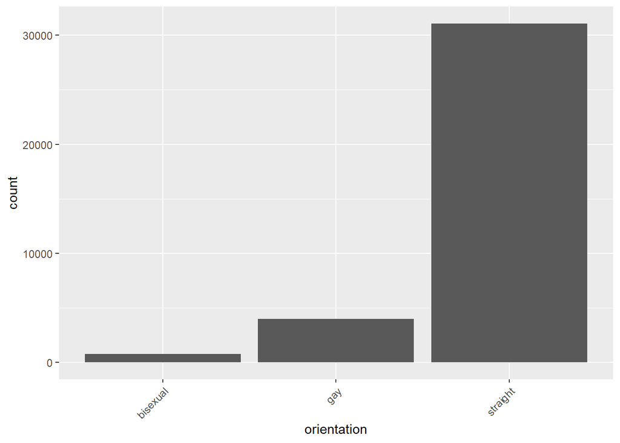

```r
ggplot(group_men, aes(x=orientation)) + geom_bar() + theme(axis.text.x = element_text(angle = 45, vjust = 1, hjust = 1))
```

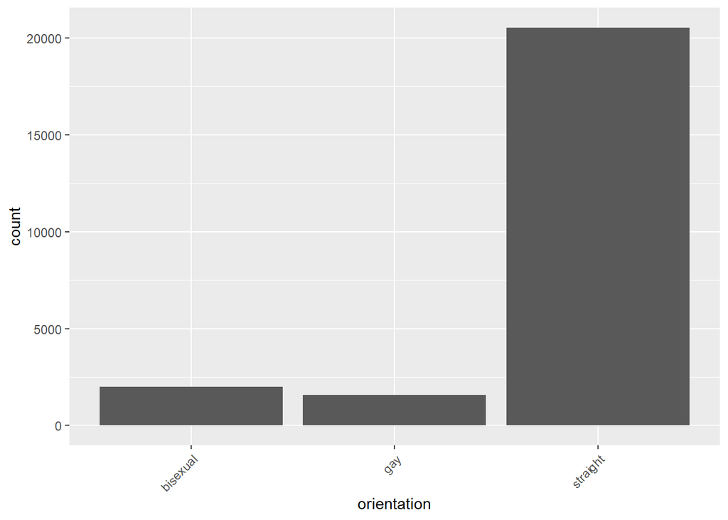

```r
ggplot(group_women, aes(x=orientation)) + geom_bar() + theme(axis.text.x = element_text(angle = 45, vjust = 1, hjust = 1))
```

```r
prop.table(table(group_men$orientation))
```

```
##
##   bisexual        gay   straight
## 0.02151888 0.11122275 0.86725837
```

```r
prop.table(table(group_women$orientation))
```

```
##
##   bisexual        gay   straight
## 0.08276320 0.06584567 0.85139113
```

Die meisten der User sind heterosexuell. Bei der Aufteilung nach Geschlecht fällt auf, dass Frauen (8.3%) vier Mal so häufig angeben bisexuell zu sein, als die Männer (2.2%). Hingegen geben Männer häufiger an homosexuell zu sein (11.1%) als die Frauen (6.6%)

## Beschreibung des Körpertyps:

```r
prop.table(table(group_men$body_type))
```

```
##
## a little extra       athletic        average          curvy            fit
##    0.054398845    0.286135516    0.271753520    0.003399928    0.249127452
##   full figured         jacked     overweight rather not say         skinny
##    0.004182212    0.008785654    0.008996269    0.002768083    0.035383319
##           thin        used up
##    0.067456974    0.007612228
```

```r
prop.table(table(group_women$body_type))
```

```
##
## a little extra       athletic        average          curvy            fit
##    0.038339404    0.107826655    0.262445129    0.177967685    0.206920706
##   full figured         jacked     overweight rather not say         skinny
##    0.040627627    0.006024096    0.006771271    0.004950033    0.028065751
##           thin        used up
##    0.115298403    0.004763239
```

Um zu sehen wie sich die beiden Geschlechter beschreiben brauchen wir uns nur den Prop-Table ansehen. Wir sehen zum Beispiel, dass Männer sich mit 28.6% als athletisch beschreiben, während nur 10.8% der Frauen diese Beschreibung wählen. Bei den Frauen tritt mit 17.8% “curvy” auf wohingegen die Männer das nur in 0.3% der Fälle angeben. Die Werte für “average” liegen ungefähr gleich bei 27.2% und 26.2%. Interessant finde ich auch, dass es ein Label gibt, das “used up” lautet, also “verbraucht”. Es wird relativ selten benutzt bei den Männern mit 0.8% jedoch häufiger als bei den Frauen mit 0.5%. Überraschend finde ich, dass nur 0.9% der Männer angeben “jacked” zu sein, was einem sehr muskulösen Körperbau entsprechen würde. 0.6% der Frauen geben an “jacked” zu sein. Hier hätte ich mir erwartet, dass das Verhältnis wesentlich größer ist. Frauen möchten fast doppelt so oft wie die Männer lieber nicht sagen (“rather not say”) wie sie sich beschreiben würden. Das kommt jedoch generell nicht so häufig vor (Männer 0.3% / Frauen 0.5%).

## Ernährungsweise:

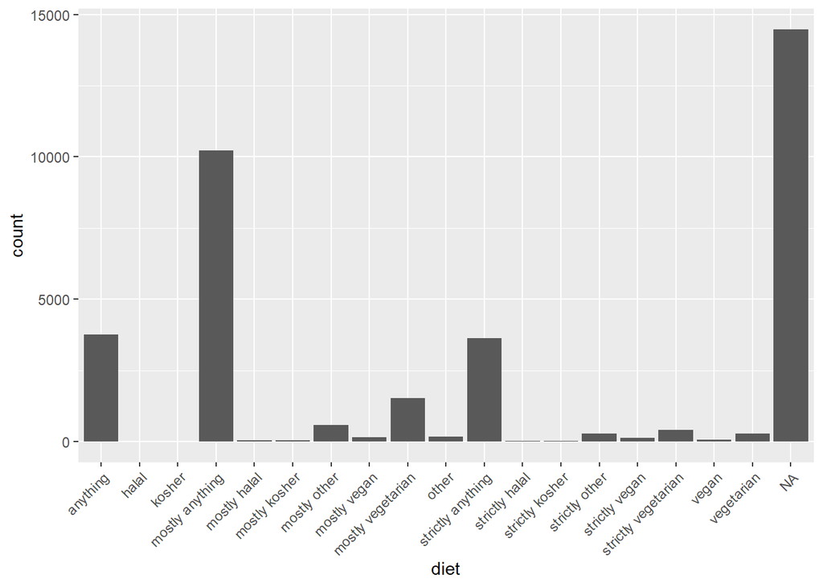

```r
ggplot(group_men, aes(x=diet)) + geom_bar() + theme(axis.text.x = element_text(angle = 45, vjust = 1, hjust = 1))
```

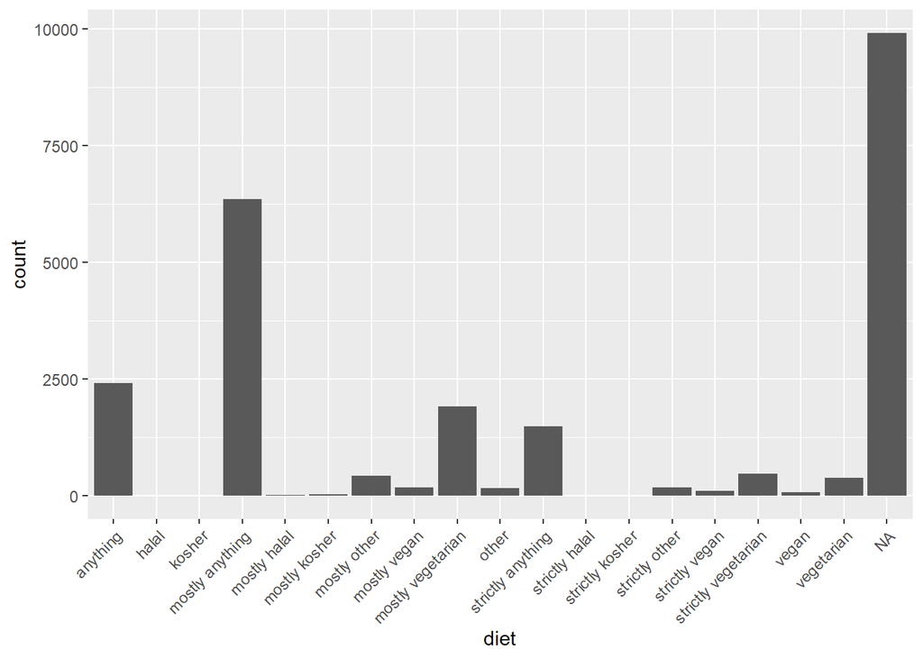

```r
ggplot(group_women, aes(x=diet)) + geom_bar() + theme(axis.text.x = element_text(angle = 45, vjust = 1, hjust = 1))
```

```r
prop.table(table(group_men$diet))
```

```
##
##            anything               halal              kosher     mostly anything
##        0.1764182321        0.0003747599        0.0002342249        0.4790837120
##        mostly halal       mostly kosher        mostly other        mostly vegan
##        0.0016864196        0.0023422495        0.0272637841        0.0073546634
##   mostly vegetarian               other   strictly anything      strictly halal
##        0.0717196796        0.0078231133        0.1702346934        0.0007495198
##     strictly kosher      strictly other      strictly vegan strictly vegetarian
##        0.0006089849        0.0128355272        0.0056682438        0.0190190659
##               vegan          vegetarian
##        0.0030449243        0.0135382021
```

```r
prop.table(table(group_women$diet))
```

```
##
##            anything               halal              kosher     mostly anything
##        0.1701633343        0.0002112081        0.0004224162        0.4476203886
##        mostly halal       mostly kosher        mostly other        mostly vegan
##        0.0008448324        0.0025344973        0.0299211490        0.0127428893
##   mostly vegetarian               other   strictly anything      strictly halal
##        0.1346803717        0.0115460434        0.1041255984        0.0001408054
##     strictly kosher      strictly other      strictly vegan strictly vegetarian
##        0.0003520135        0.0125316812        0.0075330893        0.0330188679
##               vegan          vegetarian
##        0.0049985919        0.0266122219
```

Wenn wir uns die NAs ansehen, stellen wir fest, dass die Ernährungsweise oft nicht angegeben wird. “mostly anything” und “anything” sind nach den NAs die beiden häufigsten Kategorien und sind über die Geschlechter recht gleichmäßig verteilt. Man erkennt jedoch einen Unterschied bei den Kategorien bezüglich vegetarischer und veganer Ernährung, wo die Frauen viel häufiger angeben vegetarisch oder vegan zu Essen.

## Alkoholkonsum:

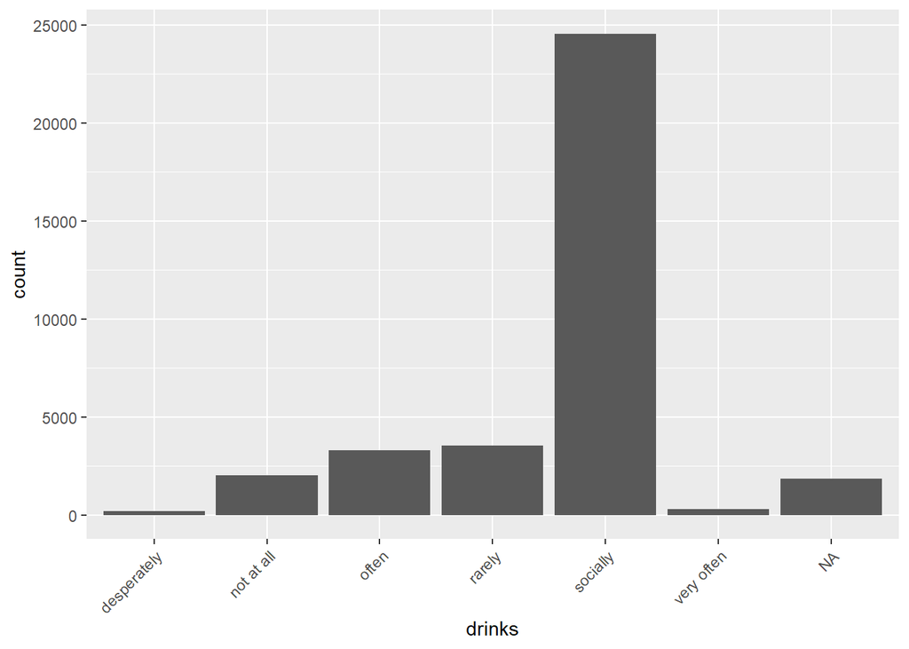

```r
ggplot(group_men, aes(x=drinks)) + geom_bar() + theme(axis.text.x = element_text(angle = 45, vjust = 1, hjust = 1))
```

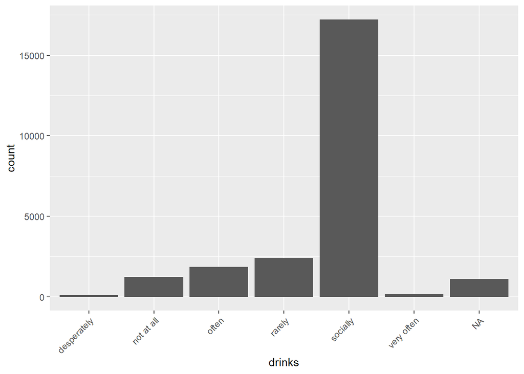

```r
ggplot(group_women, aes(x=drinks)) + geom_bar() + theme(axis.text.x = element_text(angle = 45, vjust = 1, hjust = 1))
```

```r
prop.table(table(group_men$drinks))
```

```
##
## desperately  not at all       often      rarely    socially  very often
## 0.006125574 0.059901048 0.097596890 0.104517611 0.723200613 0.008658264
```

```r
prop.table(table(group_women$drinks))
```

```
##
## desperately  not at all       often      rarely    socially  very often
## 0.004955444 0.053597044 0.080417301 0.104672897 0.748663334 0.007693980
```

Auch hier ergibt der Vergleich der Geschlechter eine recht gleichmäßige Verteilung, wobei die häufigste Kategorie “socially” mit 72.3% der Männer und 74.9% der Frauen ist. “desperately” und “often” tritt bei den Männern häufiger auf.

## Drogenkonsum:

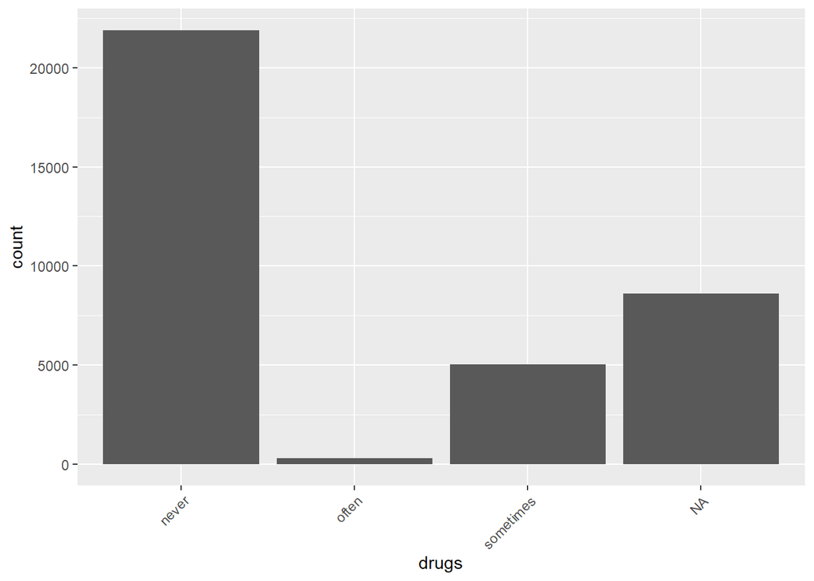

```r
ggplot(group_men, aes(x=drugs)) + geom_bar() + theme(axis.text.x = element_text(angle = 45, vjust = 1, hjust = 1))
```

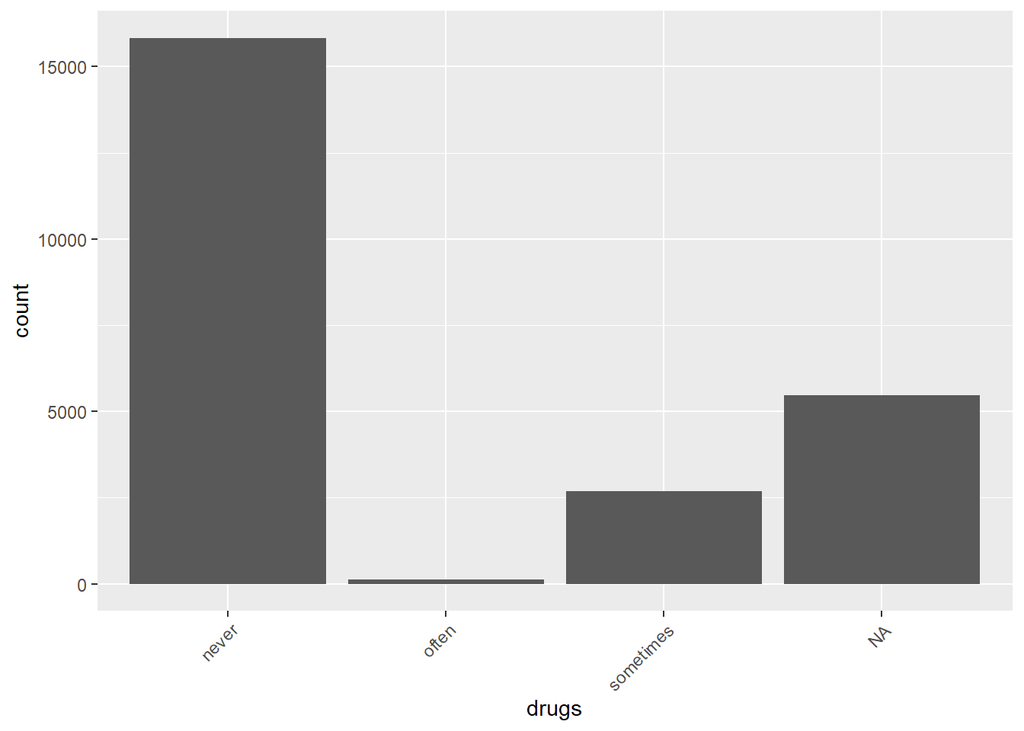

```r
ggplot(group_women, aes(x=drugs)) + geom_bar() + theme(axis.text.x = element_text(angle = 45, vjust = 1, hjust = 1))
```

```r
prop.table(table(group_men$drugs))
```

```
##
##      never      often  sometimes
## 0.80454913 0.01036231 0.18508856
```

```r
prop.table(table(group_women$drugs))
```

```
##
##       never       often   sometimes
## 0.848648938 0.006862535 0.144488527
```

Drogenkosum tritt bei Männern häufiger aus, also bei den Frauen, wobei die meisten mit über 80% bei beiden Geschlechtern angeben, nie Drogen zu konsumieren.

## Bildungsstand:

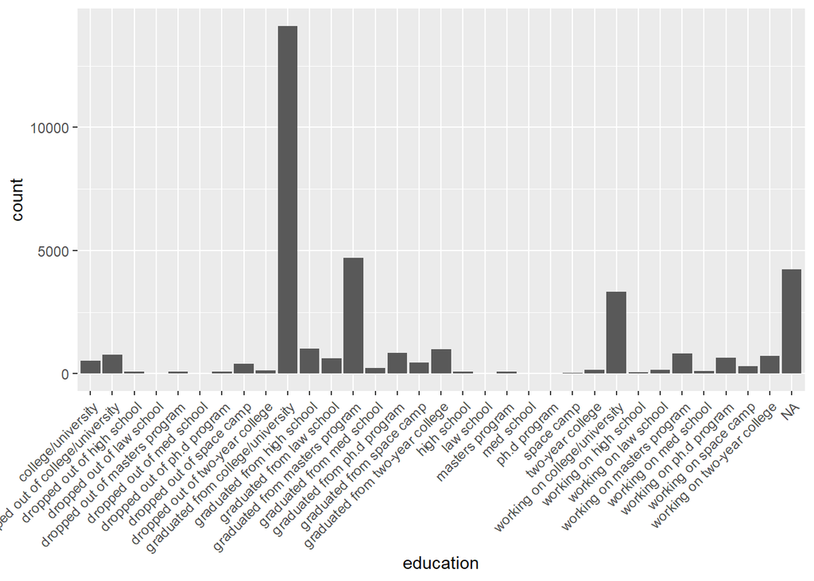

```r
ggplot(group_men, aes(x=education)) + geom_bar() + theme(axis.text.x = element_text(angle = 45, vjust = 1, hjust = 1))
```

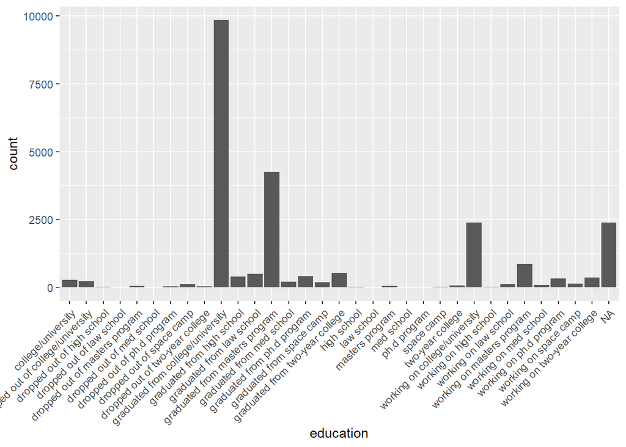

```r
ggplot(group_women, aes(x=education)) + geom_bar() + theme(axis.text.x = element_text(angle = 45, vjust = 1, hjust = 1))
```

```r
prop.table(table(group_men$education))
```

```
##
##                college/university dropped out of college/university
##                      0.0164619476                      0.0244396606
##        dropped out of high school         dropped out of law school
##                      0.0025642649                      0.0003482335
##    dropped out of masters program         dropped out of med school
##                      0.0027542105                      0.0002849183
##       dropped out of ph.d program         dropped out of space camp
##                      0.0027542105                      0.0124730910
##   dropped out of two-year college graduated from college/university
##                      0.0044953780                      0.4468785615
##        graduated from high school         graduated from law school
##                      0.0322907433                      0.0194377612
##    graduated from masters program         graduated from med school
##                      0.1487273648                      0.0075661644
##       graduated from ph.d program         graduated from space camp
##                      0.0269406104                      0.0144042041
##   graduated from two-year college                       high school
##                      0.0312460428                      0.0024059770
##                        law school                   masters program
##                      0.0004432063                      0.0024376345
##                        med school                      ph.d program
##                      0.0002532607                      0.0004432063
##                        space camp                  two-year college
##                      0.0012346461                      0.0048436115
##     working on college/university            working on high school
##                      0.1050082310                      0.0018677979
##             working on law school        working on masters program
##                      0.0047486387                      0.0259275674
##             working on med school           working on ph.d program
##                      0.0035456502                      0.0203874889
##             working on space camp       working on two-year college
##                      0.0097505382                      0.0226351779
```

```r
prop.table(table(group_women$education))
```

```
##
##                college/university dropped out of college/university
##                      0.0129314312                      0.0102623102
##        dropped out of high school         dropped out of law school
##                      0.0009664059                      0.0003221353
##    dropped out of masters program         dropped out of med school
##                      0.0024390244                      0.0001380580
##       dropped out of ph.d program         dropped out of space camp
##                      0.0018407731                      0.0059364933
##   dropped out of two-year college graduated from college/university
##                      0.0022549471                      0.4529682467
##        graduated from high school         graduated from law school
##                      0.0187758859                      0.0233778187
##    graduated from masters program         graduated from med school
##                      0.1961803958                      0.0095260009
##       graduated from ph.d program         graduated from space camp
##                      0.0193741371                      0.0092959043
##   graduated from two-year college                       high school
##                      0.0250345145                      0.0009203866
##                        law school                   masters program
##                      0.0002300966                      0.0027151404
##                        med school                      ph.d program
##                      0.0001380580                      0.0005522319
##                        space camp                  two-year college
##                      0.0008743672                      0.0031753336
##     working on college/university            working on high school
##                      0.1102162908                      0.0012885412
##             working on law school        working on masters program
##                      0.0054763000                      0.0397606995
##             working on med school           working on ph.d program
##                      0.0046019328                      0.0156005522
##             working on space camp       working on two-year college
##                      0.0063046480                      0.0165209388
```

Auch bei der Bildung sehen wir wieder viele NAs. Die häufigsten Kategorien sind ein Abschluss vom College/Universität, graduated from masters program und working on college/university. Was die erste betrifft sind die Geschlechter recht gleich verteilt. Bei den Frauen kommt ein Abschluss von einem Master jedoch häufiger vor (14.9% Männer, 19.6% Frauen). Auch bei denen, die sich gerade im Studium befinden, ist die Differenz eher gering. Bei den Männern ist die Drop-Out-Rate für diverse Bildungswege jedoch höher als bei den Frauen.

## Körpergröße:

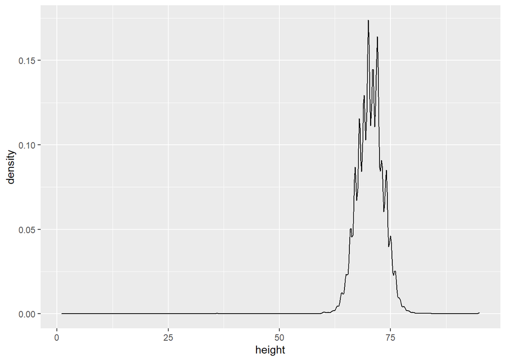

```r
ggplot(group_men, aes(x=height)) + geom_density()
```

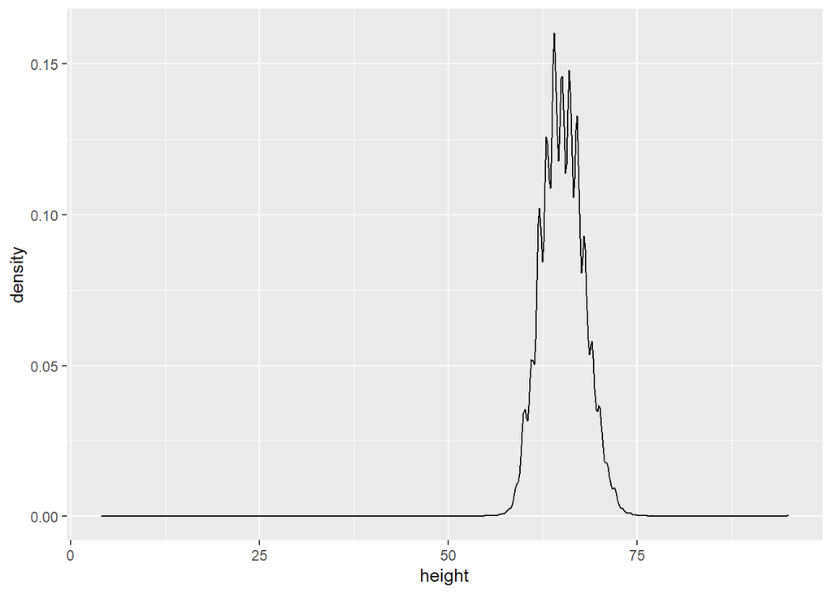

```r
ggplot(group_women, aes(x=height)) + geom_density()
```

Man sieht wie zu erwarten war, dass die Männer größer sind als die Frauen. Die Angabe erfolgt hier in Inches. Das wird für eine eventuelle Klassifikation später noch interessant.

## Einkommen:

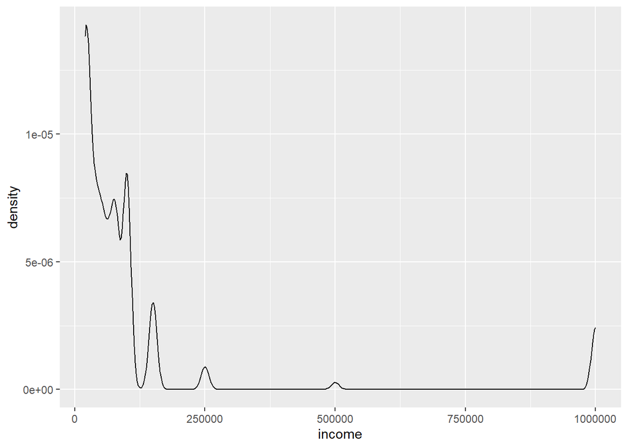

```r
# Remove -1s (would rather not say) from the Data
income_group <- subset(data, income!="-1")
income_group_men <- subset(group_men, income!="-1")
income_group_women <- subset(group_women, income!="-1")

ggplot(income_group_men, aes(x=income)) + geom_density()
```

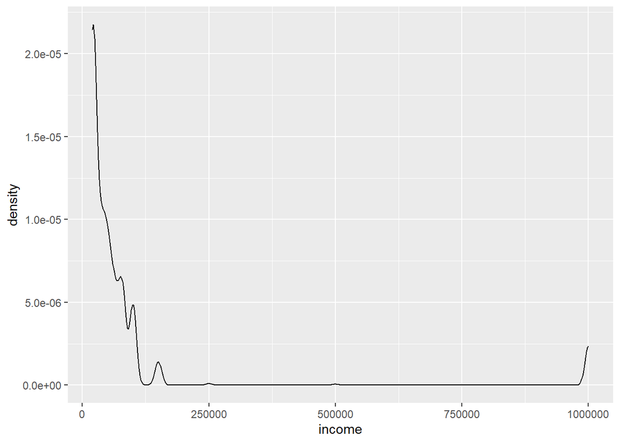

```r
ggplot(income_group_women, aes(x=income)) + geom_density()
```

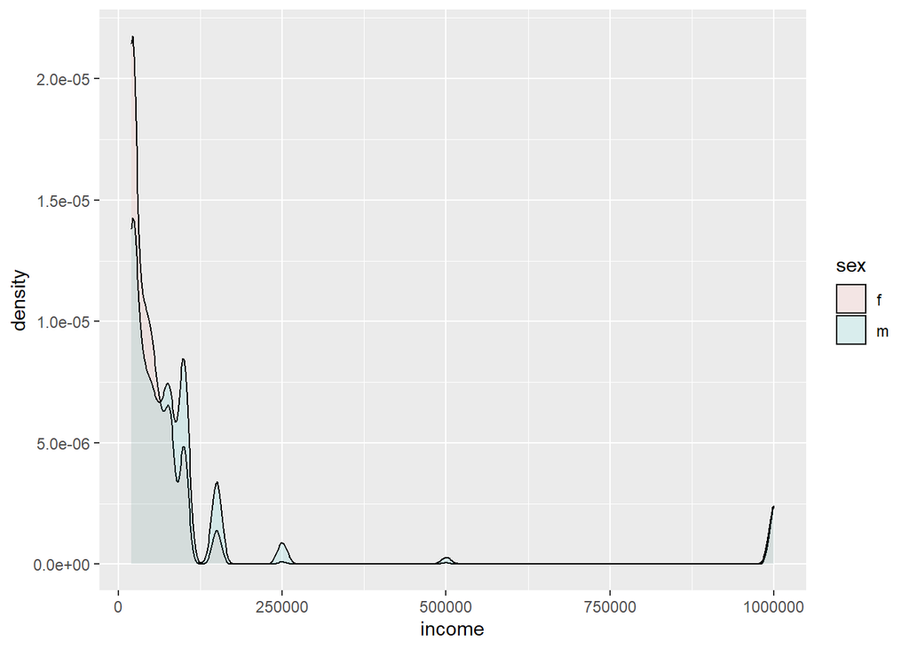

```r
ggplot(income_group, aes(x = income, fill = sex)) + geom_density(alpha = 0.1)
```

```r
mean_income_men <- mean(income_group_men$income, na.rm=T)
mean_income_women <- mean(income_group_women$income, na.rm=T)

median_income_men <- median(income_group_men$income, na.rm=T)
median_income_women <- median(income_group_women$income, na.rm=T)
```

Zunächst habe ich die Werte an -1 entfernt, weil diese Personen ihr Einkommen nicht angeben möchten. Am Ende bleiben uns bei den Männern 8391 und den Frauen 3113 übrig. Wir erkennen also, dass die überwiegende Mehrheit ihr Einkommen nicht angeben möchte. Das Verhältnis von Männern und Frauen ist auch ungleich, was bei der Interpretation der Ergebnisse eine wichtige Rolle spielt. Die Aussagen sind mit Vorsicht zu genießen.Schauen wir uns die resultierenden Graphen an, so stellen wir fest, dass die Männer ein höheres Einkommen haben (siehe auch Media und Mean). Das ist nicht überraschend. Der Graph zeigt auch, dass die Angabe in Einkommens-Kategorien erfolgt, wir haben also diverse Spitzen im Graph.

## Kinder und Kinderwunsch:

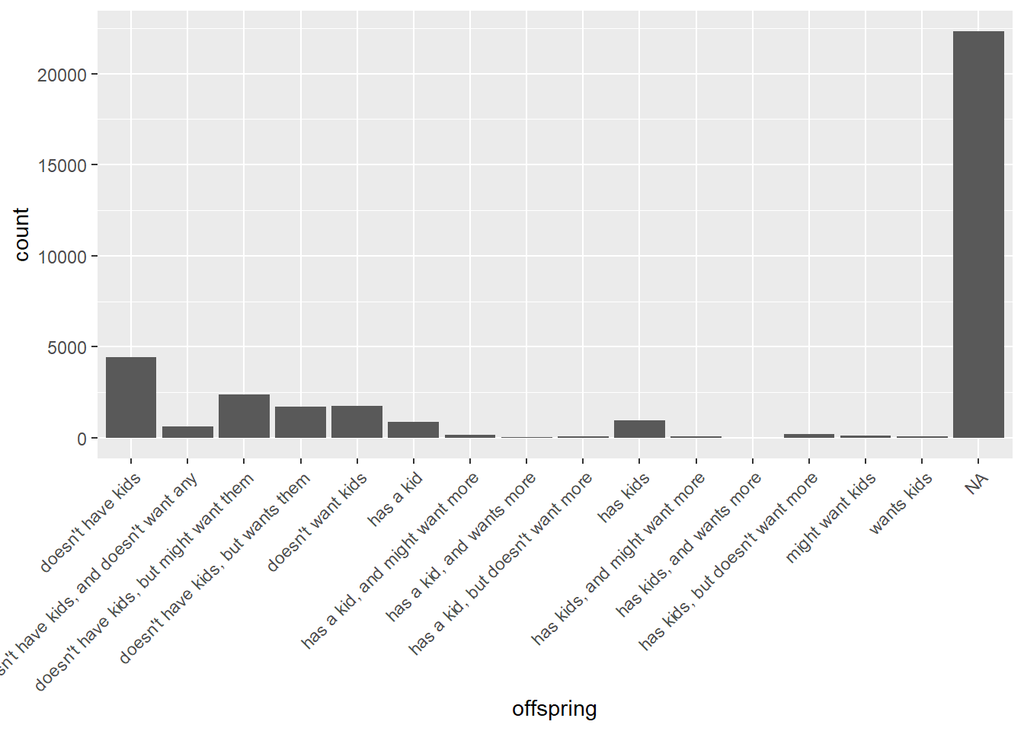

```r
ggplot(group_men, aes(x=offspring)) + geom_bar() + theme(axis.text.x = element_text(angle = 45, vjust = 1, hjust = 1))
```

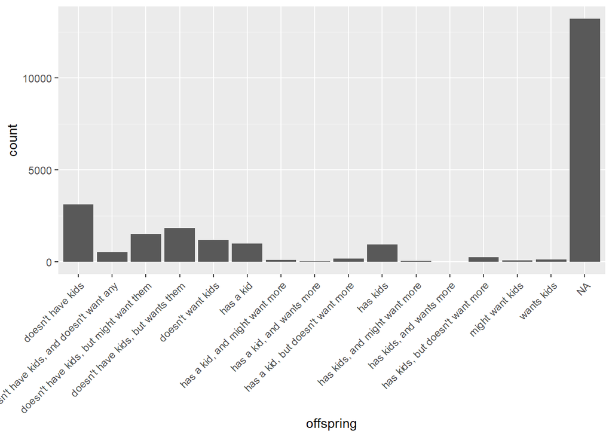

```r
ggplot(group_women, aes(x=offspring)) + geom_bar() + theme(axis.text.x = element_text(angle = 45, vjust = 1, hjust = 1))
```

```r
prop.table(table(group_men$offspring))
```

```
##
##                       doesn't have kids doesn't have kids, and doesn't want any
##                            0.3286889498                            0.0462462017
##  doesn't have kids, but might want them       doesn't have kids, but wants them
##                            0.1755725191                            0.1278440673
##                       doesn't want kids                               has a kid
##                            0.1296968799                            0.0655154525
##          has a kid, and might want more               has a kid, and wants more
##                            0.0104498629                            0.0033350626
##        has a kid, but doesn't want more                                has kids
##                            0.0071889128                            0.0696657526
##           has kids, and might want more                has kids, and wants more
##                            0.0051137627                            0.0009634625
##         has kids, but doesn't want more                         might want kids
##                            0.0138590380                            0.0088935003
##                              wants kids
##                            0.0069665753
```

```r
prop.table(table(group_women$offspring))
```

```
##
##                       doesn't have kids doesn't have kids, and doesn't want any
##                             0.286907822                             0.046639736
##  doesn't have kids, but might want them       doesn't have kids, but wants them
##                             0.138266618                             0.168931326
##                       doesn't want kids                               has a kid
##                             0.108060962                             0.091535072
##          has a kid, and might want more               has a kid, and wants more
##                             0.008262945                             0.002387073
##        has a kid, but doesn't want more                                has kids
##                             0.016342270                             0.086577304
##           has kids, and might want more                has kids, and wants more
##                             0.004223283                             0.000734484
##         has kids, but doesn't want more                         might want kids
##                             0.023411678                             0.005692251
##                              wants kids
##                             0.012027176
```

## Haustiere:

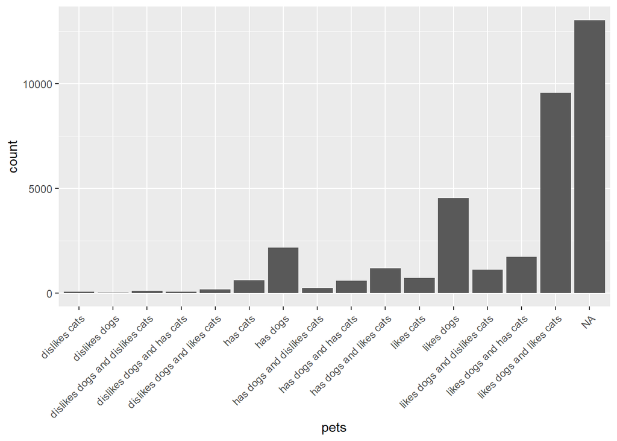

```r
ggplot(group_men, aes(x=pets)) + geom_bar() + theme(axis.text.x = element_text(angle = 45, vjust = 1, hjust = 1))
```

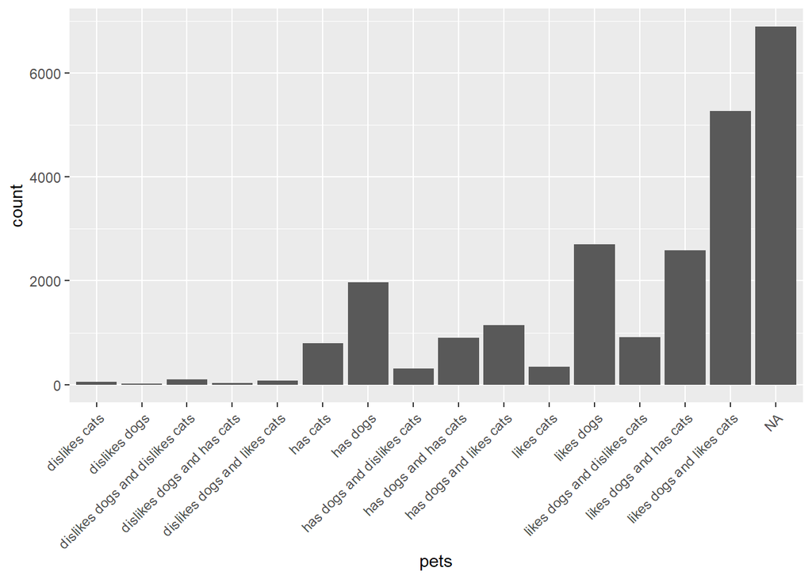

```r
ggplot(group_women, aes(x=pets)) + geom_bar() + theme(axis.text.x = element_text(angle = 45, vjust = 1, hjust = 1))
```

```r
prop.table(table(group_men$pets))
```

```
##
##                   dislikes cats                   dislikes dogs
##                    0.0028062790                    0.0009646584
## dislikes dogs and dislikes cats      dislikes dogs and has cats
##                    0.0044286591                    0.0021485574
##    dislikes dogs and likes cats                        has cats
##                    0.0072349382                    0.0267911953
##                        has dogs      has dogs and dislikes cats
##                    0.0950188547                    0.0104358502
##           has dogs and has cats         has dogs and likes cats
##                    0.0253003596                    0.0518723143
##                      likes cats                      likes dogs
##                    0.0313952469                    0.1983688503
##    likes dogs and dislikes cats         likes dogs and has cats
##                    0.0487152504                    0.0757695343
##       likes dogs and likes cats
##                    0.4187494519
```

```r
prop.table(table(group_women$pets))
```

```
##
##                   dislikes cats                   dislikes dogs
##                     0.003368372                     0.001277658
## dislikes dogs and dislikes cats      dislikes dogs and has cats
##                     0.005517161                     0.001858412
##    dislikes dogs and likes cats                        has cats
##                     0.004355654                     0.046169929
##                        has dogs      has dogs and dislikes cats
##                     0.114234276                     0.018235670
##           has dogs and has cats         has dogs and likes cats
##                     0.052093618                     0.066786689
##                      likes cats                      likes dogs
##                     0.020152158                     0.156803531
##    likes dogs and dislikes cats         likes dogs and has cats
##                     0.053313201                     0.150124862
##       likes dogs and likes cats
##                     0.305708810
```

## Religionszugehörigkeit:

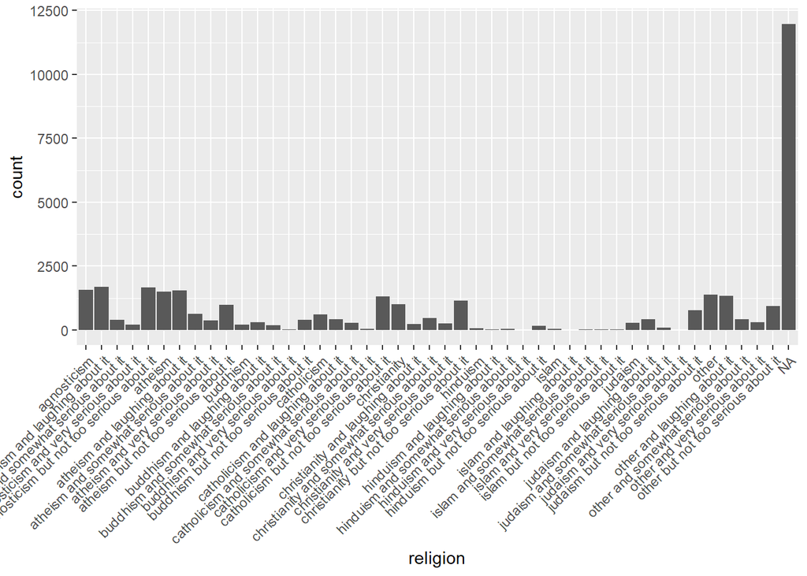

```r
ggplot(group_men, aes(x=religion)) + geom_bar() + theme(axis.text.x = element_text(angle = 45, vjust = 1, hjust = 1))
```

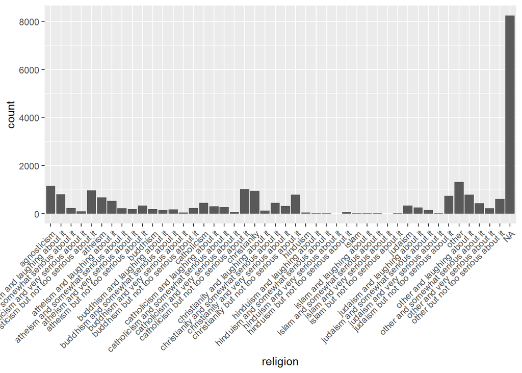

```r
ggplot(group_women, aes(x=religion)) + geom_bar() + theme(axis.text.x = element_text(angle = 45, vjust = 1, hjust = 1))
```

```r
prop.table(table(group_men$religion))
```

```
##
##                                agnosticism
##                               0.0658308524
##          agnosticism and laughing about it
##                               0.0707786490
##  agnosticism and somewhat serious about it
##                               0.0170657051
##      agnosticism and very serious about it
##                               0.0090569835
##   agnosticism but not too serious about it
##                               0.0699400394
##                                    atheism
##                               0.0629376494
##              atheism and laughing about it
##                               0.0646148685
##      atheism and somewhat serious about it
##                               0.0261646191
##          atheism and very serious about it
##                               0.0160174431
##       atheism but not too serious about it
##                               0.0412176611
##                                   buddhism
##                               0.0085957482
##             buddhism and laughing about it
##                               0.0125372133
##     buddhism and somewhat serious about it
##                               0.0079248606
##         buddhism and very serious about it
##                               0.0012159839
##      buddhism but not too serious about it
##                               0.0169818441
##                                catholicism
##                               0.0254098704
##          catholicism and laughing about it
##                               0.0178623842
##  catholicism and somewhat serious about it
##                               0.0115308818
##      catholicism and very serious about it
##                               0.0018868716
##   catholicism but not too serious about it
```

[output cut: 36 more lines]

```
##                               0.0042769089
##          judaism and very serious about it
##                               0.0002515829
##       judaism but not too serious about it
##                               0.0322445386
##                                      other
##                               0.0575705480
##                other and laughing about it
##                               0.0558933289
##        other and somewhat serious about it
##                               0.0174850099
##            other and very serious about it
##                               0.0128726571
##         other but not too serious about it
##                               0.0394146505
```

```r
prop.table(table(group_women$religion))
```

```
##
##                                agnosticism
##                                0.072711234
##          agnosticism and laughing about it
##                                0.050910466
##  agnosticism and somewhat serious about it
##                                0.014806880
##      agnosticism and very serious about it
##                                0.006174784
##   agnosticism but not too serious about it
##                                0.060991746
##                                    atheism
##                                0.042467393
##              atheism and laughing about it
##                                0.033583265
##      atheism and somewhat serious about it
##                                0.014113792
##          atheism and very serious about it
##                                0.011845504
##       atheism but not too serious about it
##                                0.021107681
##                                   buddhism
##                                0.012475584
##             buddhism and laughing about it
##                                0.010522336
##     buddhism and somewhat serious about it
##                                0.010711360
##         buddhism and very serious about it
##                                0.002583328
##      buddhism but not too serious about it
##                                0.015436960
##                                catholicism
##                                0.028857665
##          catholicism and laughing about it
##                                0.018902401
##  catholicism and somewhat serious about it
##                                0.017201185
##      catholicism and very serious about it
##                                0.003591456
##   catholicism but not too serious about it
```

[output cut: 36 more lines]

```
##                                0.010333312
##          judaism and very serious about it
##                                0.001008128
##       judaism but not too serious about it
##                                0.047129986
##                                      other
##                                0.083044547
##                other and laughing about it
##                                0.049524290
##        other and somewhat serious about it
##                                0.027030433
##            other and very serious about it
##                                0.014239808
##         other but not too serious about it
##                                0.038686913
```

Da auch hier wieder viele NAs vorhanden sind und eine Vielzahl an Antwortkategorien vorhanden ist, bin ich skeptisch ob hier viel für eine Klassifikation zu holen ist.

## Sternzeichen:

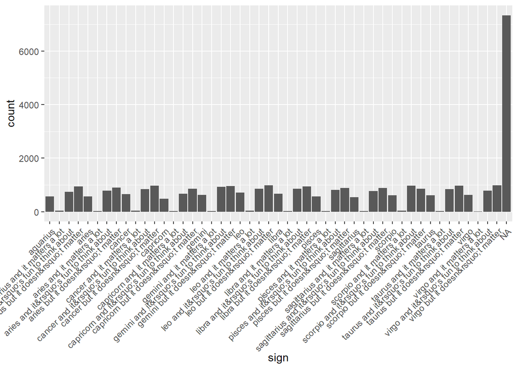

```r
ggplot(group_men, aes(x=sign)) + geom_bar() + theme(axis.text.x = element_text(angle = 45, vjust = 1, hjust = 1))
```

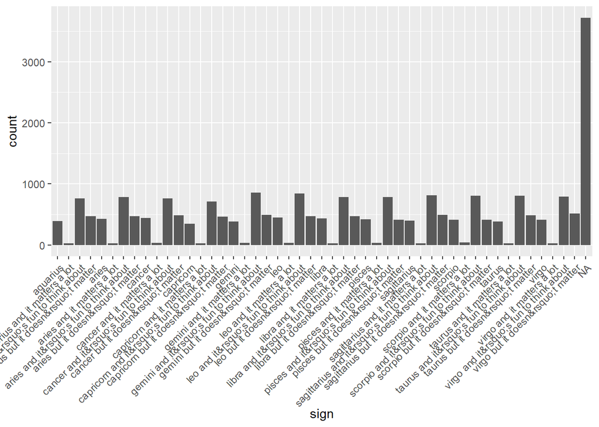

```r
ggplot(group_women, aes(x=sign)) + geom_bar() + theme(axis.text.x = element_text(angle = 45, vjust = 1, hjust = 1))
```

```r
prop.table(table(group_men$sign))
```

```
##
##                                      aquarius
##                                  0.0197220663
##                 aquarius and it matters a lot
##                                  0.0012984278
##    aquarius and it&rsquo;s fun to think about
##                                  0.0259334643
##          aquarius but it doesn&rsquo;t matter
##                                  0.0329870859
##                                         aries
##                                  0.0200729927
##                    aries and it matters a lot
##                                  0.0007018529
##       aries and it&rsquo;s fun to think about
##                                  0.0276530039
##             aries but it doesn&rsquo;t matter
##                                  0.0317237507
##                                        cancer
##                                  0.0228453116
##                   cancer and it matters a lot
##                                  0.0011229646
##      cancer and it&rsquo;s fun to think about
##                                  0.0293374509
##            cancer but it doesn&rsquo;t matter
##                                  0.0339345873
##                                     capricorn
##                                  0.0170901179
##                capricorn and it matters a lot
##                                  0.0007018529
##   capricorn and it&rsquo;s fun to think about
##                                  0.0233015160
##         capricorn but it doesn&rsquo;t matter
##                                  0.0301094891
##                                        gemini
##                                  0.0220030882
##                   gemini and it matters a lot
##                                  0.0009825940
##      gemini and it&rsquo;s fun to think about
##                                  0.0323554183
##            gemini but it doesn&rsquo;t matter
```

[output cut: 42 more lines]

```
##                                  0.0216521617
##                   taurus and it matters a lot
##                                  0.0007720382
##      taurus and it&rsquo;s fun to think about
##                                  0.0293374509
##            taurus but it doesn&rsquo;t matter
##                                  0.0339345873
##                                         virgo
##                                  0.0217223470
##                    virgo and it matters a lot
##                                  0.0004912970
##       virgo and it&rsquo;s fun to think about
##                                  0.0273722628
##             virgo but it doesn&rsquo;t matter
##                                  0.0346013476
```

```r
prop.table(table(group_women$sign))
```

```
##
##                                      aquarius
##                                   0.019221340
##                 aquarius and it matters a lot
##                                   0.001274885
##    aquarius and it&rsquo;s fun to think about
##                                   0.037461999
##          aquarius but it doesn&rsquo;t matter
##                                   0.022947926
##                                         aries
##                                   0.020790429
##                    aries and it matters a lot
##                                   0.001323919
##       aries and it&rsquo;s fun to think about
##                                   0.038491713
##             aries but it doesn&rsquo;t matter
##                                   0.022996960
##                                        cancer
##                                   0.021624007
##                   cancer and it matters a lot
##                                   0.001520055
##      cancer and it&rsquo;s fun to think about
##                                   0.037314897
##            cancer but it doesn&rsquo;t matter
##                                   0.023879572
##                                     capricorn
##                                   0.016965774
##                capricorn and it matters a lot
##                                   0.001225851
##   capricorn and it&rsquo;s fun to think about
##                                   0.034912229
##         capricorn but it doesn&rsquo;t matter
##                                   0.022604688
##                                        gemini
##                                   0.018927135
##                   gemini and it matters a lot
##                                   0.001667157
##      gemini and it&rsquo;s fun to think about
##                                   0.042169265
##            gemini but it doesn&rsquo;t matter
```

[output cut: 42 more lines]

```
##                                   0.018829067
##                   taurus and it matters a lot
##                                   0.001323919
##      taurus and it&rsquo;s fun to think about
##                                   0.039423360
##            taurus but it doesn&rsquo;t matter
##                                   0.023683436
##                                         virgo
##                                   0.020103952
##                    virgo and it matters a lot
##                                   0.001323919
##       virgo and it&rsquo;s fun to think about
##                                   0.038933020
##             virgo but it doesn&rsquo;t matter
##                                   0.025056389
```

Hier war zu erwarten, dass die Häufigkeit der Sternzeichen einer Gleichverteilung entpsircht und das bestätigt sich auch. Bei beiden Geschlechtern ist zu erkennen, dass ihnen die Beuteutung des Sternzeichens nicht sehr wichtig ist, Frau geben jedoch häufiger an, dass ihnen Spaß macht sich darüber Gedanken zu machen, was für eine Klassifikation interessant sein könnte.

## Raucher:

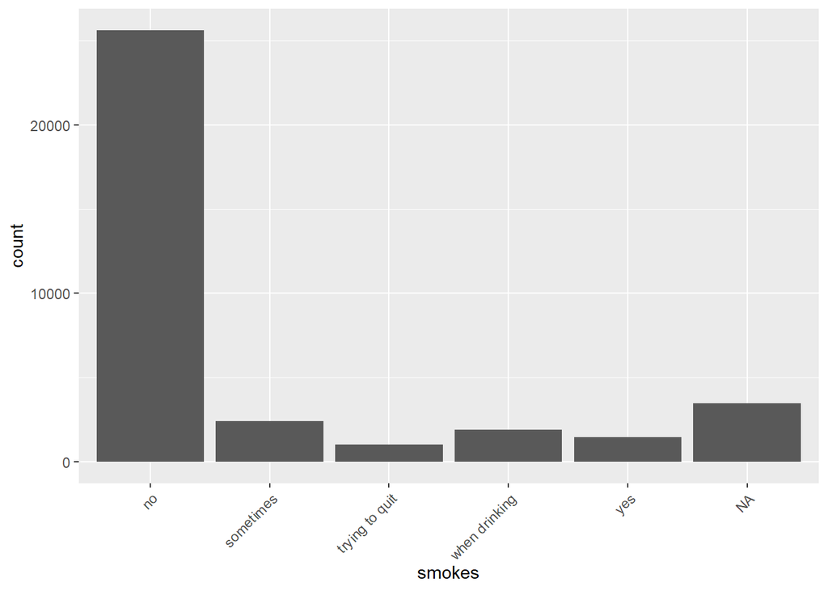

```r
ggplot(group_men, aes(x=smokes)) + geom_bar() + theme(axis.text.x = element_text(angle = 45, vjust = 1, hjust = 1))
```

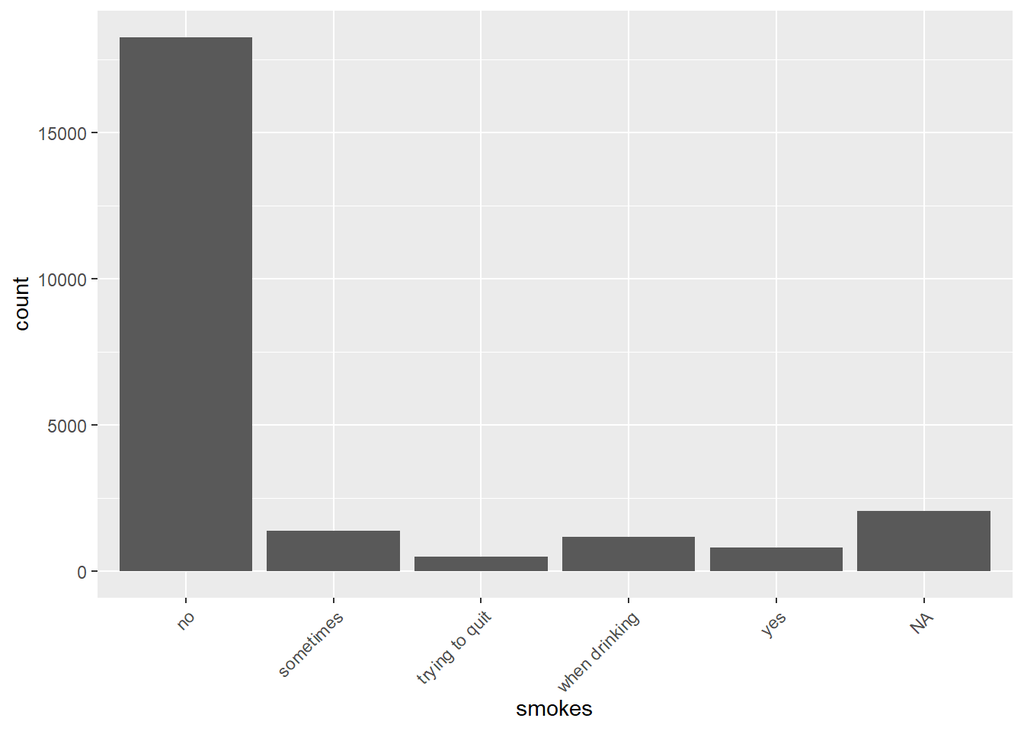

```r
ggplot(group_women, aes(x=smokes)) + geom_bar() + theme(axis.text.x = element_text(angle = 45, vjust = 1, hjust = 1))
```

```r
prop.table(table(group_men$smokes))
```

```
##
##             no      sometimes trying to quit  when drinking            yes
##     0.79196144     0.07479378     0.03089376     0.05801847     0.04433254
```

```r
prop.table(table(group_women$smokes))
```

```
##
##             no      sometimes trying to quit  when drinking            yes
##     0.82760027     0.06190800     0.02175391     0.05266259     0.03607523
```

Was das Rauchen betrifft, sehen wir kaum einen Unterschied zwischen den Geschlechtern. Ich bin jedoch überrascht, dass es nur so wenige Raucher sind.

Ethnie, Standort, letztes mal online, Beruf und Sprachen habe ich nicht weiter analysiert, weil sie entweder nicht vielversprechend für eine Klassifikation sind, sehr viele NAs enthalten oder so viele Ausprägungen haben, dass man die gesamte Variable erst mal neu aufteilen müsste. Die Essayfragen habe ich ebenfalls nicht näher betrachtet, weil es hier schon sehr qualitativ wird und das den Rahmen dieses Projekts sprengen würde.

## Klassifikation mittels logisitischer Regression

Die logistische Regression sollte hier eine gute Möglichkeit bieten, ein Model zu erstellen, dass anhand der in der EDA untersuchten Variablen vorhersagen kann, ob es sich um einen Mann oder eine Frau handelt.

```r
okcupid_profiles <- data %>% select(age, status, sex, orientation, body_type, diet, drinks, drugs, education, height, income, offspring, pets, sign) %>% drop_na()

prop.table(table(okcupid_profiles$sex))
```

```
##
##         f         m
## 0.4601359 0.5398641
```

Zunächst hole ich mir alle Variablen, die mich interessieren könnten und schauen wie viele übrig bleiben, wenn ich die NAs entferne. 9269 bleiben übrig, was auf jeden Fall ausreichend sein sollte. Klassenverteilung ist relativ ähnlich und sollte so in Ordnung sein.

```r
set.seed(1303)

# Geschlecht als Faktorvariable setzen
okcupid_profiles$sex <- as.factor(okcupid_profiles$sex)

# Trainings- und Test-Datensplit
temp <- sample(nrow(okcupid_profiles), nrow(okcupid_profiles)*.8)

trn_data <- okcupid_profiles[temp,]
prop.table(table(trn_data$sex))
```

```
##
##         f         m
## 0.4590695 0.5409305
```

```r
tst_data <- okcupid_profiles[-temp,]
prop.table(table(tst_data$sex))
```

```
##
##         f         m
## 0.4644013 0.5355987
```

Verteilung der Geschlechter ist im Trainings- und Testdatensatz auch ok. Es wurde ein Split von 80/20 für Trainings und Testdaten gewählt, was zu zwei ausreichend großen Daten-Sets geführt hat. Zuvor habe ich es mit einem 70/30 Split versucht, die Accuracy ist mit 80/20 jedoch ein bisschen besser und nachdem immer noch 1854 Test-Daten vorhanden sind, entscheide ich mich für letzteren.

```r
# Create and fit model
logistic_model <- glm(sex ~ age + orientation + body_type + height + pets + income + drugs + drinks + education + offspring + diet, family = "binomial", data=trn_data)
summary(logistic_model)
```

```
##
## Call:
## glm(formula = sex ~ age + orientation + body_type + height +
##     pets + income + drugs + drinks + education + offspring +
##     diet, family = "binomial", data = trn_data)
##
## Deviance Residuals:
##     Min       1Q   Median       3Q      Max
## -6.6625  -0.3295   0.0738   0.4094   5.4434
##
## Coefficients:
##                                                    Estimate Std. Error z value
## (Intercept)                                      -4.570e+01  1.622e+00 -28.170
## age                                               4.840e-03  5.043e-03   0.960
## orientationgay                                    2.352e+00  2.504e-01   9.391
## orientationstraight                               1.505e+00  1.991e-01   7.562
## body_typeathletic                                 4.950e-01  1.730e-01   2.861
## body_typeaverage                                 -8.677e-02  1.623e-01  -0.535
## body_typecurvy                                   -4.984e+00  4.114e-01 -12.115
## body_typefit                                      1.740e-01  1.683e-01   1.034
## body_typefull figured                            -3.503e+00  3.970e-01  -8.824
## body_typejacked                                   2.970e-02  4.425e-01   0.067
## body_typeoverweight                               2.677e-01  3.971e-01   0.674
## body_typerather not say                           1.274e-01  6.465e-01   0.197
## body_typeskinny                                  -6.139e-02  2.620e-01  -0.234
## body_typethin                                    -9.726e-01  1.992e-01  -4.883
## body_typeused up                                 -2.202e-01  4.899e-01  -0.449
## height                                            6.654e-01  1.736e-02  38.337
## petsdislikes dogs                                -8.226e-01  1.544e+00  -0.533
## petsdislikes dogs and dislikes cats              -1.212e+00  9.608e-01  -1.261
## petsdislikes dogs and has cats                   -2.201e+00  1.255e+00  -1.754
## petsdislikes dogs and likes cats                 -1.686e-01  1.002e+00  -0.168
## petshas cats                                     -1.733e+00  8.980e-01  -1.929
## petshas dogs                                     -1.348e+00  8.790e-01  -1.534
## petshas dogs and dislikes cats                   -1.563e+00  9.134e-01  -1.711
## petshas dogs and has cats                        -1.989e+00  8.930e-01  -2.227
## petshas dogs and likes cats                      -1.156e+00  8.828e-01  -1.309
## petslikes cats                                   -7.978e-01  9.075e-01  -0.879
## petslikes dogs                                   -9.500e-01  8.744e-01  -1.087
## petslikes dogs and dislikes cats                 -1.015e+00  8.837e-01  -1.149
```

[output cut: 166 more lines]

```
## dietstrictly other                               0.656537
## dietstrictly vegan                               0.646779
## dietstrictly vegetarian                          0.058309 .
## dietvegan                                        0.024785 *
## dietvegetarian                                   0.024552 *
## ---
## Signif. codes:  0 '***' 0.001 '**' 0.01 '*' 0.05 '.' 0.1 ' ' 1
##
## (Dispersion parameter for binomial family taken to be 1)
##
##     Null deviance: 10229.6  on 7414  degrees of freedom
## Residual deviance:  4366.6  on 7316  degrees of freedom
## AIC: 4564.6
##
## Number of Fisher Scoring iterations: 13
```

Hier habe ich zunächst mal alle der Variablen verwendet, die ich mir im letzten Schritt rausgeholt hat und dann nach und nach die rausgegeben, die das Model nicht verbessert haben. Man erkennt, dass durch die vielen kategorischen Variabeln oft nicht signifikante Werte enthalten sind, ingesamt können einzelne Antwortvariablen jedoch einen sehr guten Indikator für Geschlecht darstellen. Vegetarische oder Vegane Ernährung, als auch Körpertyp-Beschreibung wären zwei gute Beispiele.

```r
# Test Model

predict <- predict(logistic_model, newdata=tst_data, type="response")

table_mat <- table(tst_data$sex, predict > 0.5)
table_mat
```

```
##
##     FALSE TRUE
##   f   733  128
##   m   122  871
```

```r
accuracy_Test <- sum(diag(table_mat)) / sum(table_mat)
accuracy_Test
```

```
## [1] 0.8651564
```

Das Model auf das ich mich am Eende festgelegt habe hat eine Accuracy von 87% was kein schlechter Wert ist. Ich denke man könnte noch einen höheren Wert erreichen, wenn man die Essay-Fragen auf eine sinnvolle Weise inkludiert.

```r
# Schauen wir uns auch noch precision und recall an:

precision <- function(matrix) {
    # True positive
    tp <- matrix[2, 2]
    # false positive
    fp <- matrix[1, 2]
    return (tp / (tp + fp))
}

recall <- function(matrix) {
# true positive
    tp <- matrix[2, 2]# false positive
    fn <- matrix[2, 1]
    return (tp / (tp + fn))
}

prec <- precision(table_mat)
prec
```

```
## [1] 0.8718719
```

```r
rec <- recall(table_mat)
rec
```

```
## [1] 0.87714
```

Diese Werte sind meiner Meinung nach auch völlig akzeptabel, precision liegt bei 87% und recall bei 88%.

Die Klassifikation mittels logistischer Regression kann als Erfolgreich betrachtet werden. Wie bereits vorhin erwähnt, könnte man mittels der Essay-Fragen noch mehr raus holen, was jedoch viel qualitative Interpretation bräuchte. Die Variablen könnten auch noch sauberer aufgeteilt werden.